# Ds202_lab2_team question

4 . How do ratings compare across different company locations? Focus on the three locations with the most ratings. Hint: the function sort() might come in handy here.

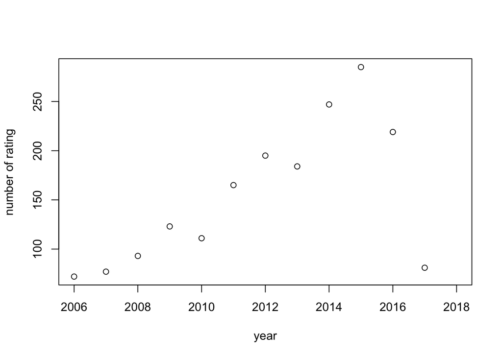

```r
t2<-table(choco$Rating,choco$Company.Location)
tab2<-colSums(t2)
t2<-data.frame(tab)
year=seq(2006,2017,1)
plot(year,t1$tab,xlab="year",ylab="number of rating",xlim=c(2006,2018))
```

```r
t2<-table(choco$Rating,choco$Company.Location)
tab1<-colSums(t2)
sort(tab1,decreasing = TRUE)
```

```
##            U.S.A.            France            Canada              U.K.
##               787               158               132                98
##             Italy           Ecuador         Australia           Belgium
##                69                55                50                40
##       Switzerland           Germany           Austria             Spain
##                38                36                27                26
##          Colombia           Hungary         Venezuela            Brazil
##                23                23                20                18
##             Japan        Madagascar       New Zealand              Peru
##                17                17                17                17
##           Denmark           Vietnam         Guatemala          Scotland
##                16                11                10                10
##         Argentina        Costa Rica            Israel            Poland
##                 9                 9                 9                 8
##         Amsterdam          Honduras         Lithuania Domincan Republic
##                 6                 6                 6                 5
##         Nicaragua       South Korea            Sweden              Fiji
##                 5                 5                 5                 4
##           Ireland            Mexico       Netherlands       Puerto Rico
##                 4                 4                 4                 4
##          Sao Tome            U.A.E.           Grenada           Iceland
##                 4                 4                 3                 3
##          Portugal            Russia         Singapore      South Africa
##                 3                 3                 3                 3
##           Bolivia             Chile           Finland             India
##                 2                 2                 2                 2
##         St. Lucia    Czech Republic           Eucador             Ghana
##                 2                 1                 1                 1
##        Martinique         Niacragua       Philippines          Suriname
##                 1                 1                 1                 1
##             Wales
##                 1
```

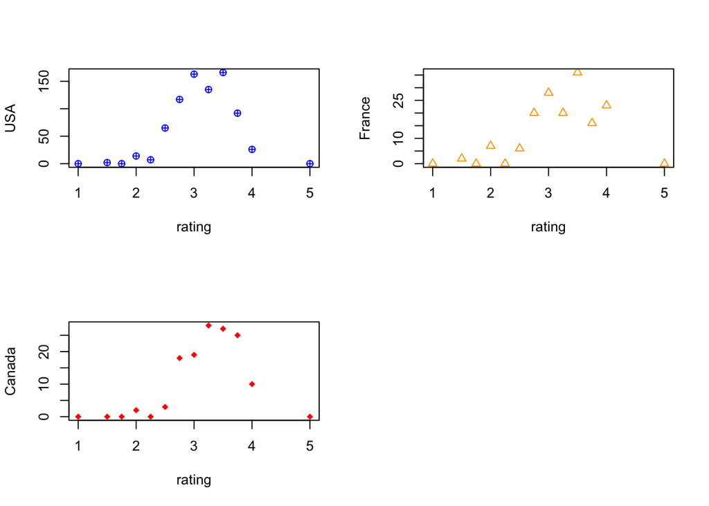

```r
con<-cbind(t2[,"U.S.A."],t2[,"France"],t2[,"Canada"])
con<-data.frame(con)
ra<-sort(unique(choco$Rating),decreasing=FALSE)
par(mfrow=c(2,2))
plot(ra,con$X1,pch=10,col='blue',xlim=c(1,5),xlab="rating",ylab='USA')
plot(ra,con$X2,pch=2,col='orange',xlab="rating",ylab='France')
plot(ra,con$X3,pch=18,col='red',xlab="rating",ylab='Canada')
```

The three locations with the most ratings are the U.S.A, France, and Canada. Based on the plots we get, the common trend they all share is that most rating scores are spread among 2-4, and mainly at 3.

5 . Brainstorm and write down an interesting question that can be answer from the dataset. The question should not duplicate the questions above.

What is the relationship between the specific been origin and rating?

6 . Bonus points (optional): Answer the question from the dataset.